# titanic_analysis

### TITANIC SURVIVAL - EXPLORATORY DATA ANALYSIS

### Project Overview:

This analysis explores the factors that influenced passenger survival on the Titanic.

### Dataset Information:

- **Source**: Kaggle Titanic dataset
- **Records**: 887 passengers
- **Features**: 8 original columns
- **Target Variable**: Survived (0 = No, 1 = Yes)

### Analysis Objectives:

1. Perform comprehensive univariate analysis
2. Identify key survival factors through multivariate analysis
3. Create meaningful visualizations
4. Derive actionable insights

```python
import pandas as pd
import numpy as np
import matplotlib.pyplot as plt
import seaborn as sns
sns.set_style("whitegrid")

# Configuration
pd.set_option('display.max_columns', None)
plt.rcParams['figure.figsize'] = (10, 6)

df = pd.read_csv('titanic.csv')
print(f"Dataset shape: {df.shape}")
```

```
Dataset shape: (887, 8)
```

### DATA PRE-PROCESSING

```python
print("\n1. Initial Data Inspection:")
print("=" * 30)
print(df.head())
print("\nData Types:")
print(df.dtypes)
```

```
1. Initial Data Inspection:
==============================
   Survived  Pclass                                               Name  \
0         0       3                             Mr. Owen Harris Braund
1         1       1  Mrs. John Bradley (Florence Briggs Thayer) Cum...
2         1       3                              Miss. Laina Heikkinen
3         1       1        Mrs. Jacques Heath (Lily May Peel) Futrelle
4         0       3                            Mr. William Henry Allen

      Sex   Age  Siblings/Spouses Aboard  Parents/Children Aboard     Fare
0    male  22.0                        1                        0   7.2500
1  female  38.0                        1                        0  71.2833
2  female  26.0                        0                        0   7.9250
3  female  35.0                        1                        0  53.1000
4    male  35.0                        0                        0   8.0500

Data Types:
Survived                     int64
Pclass                       int64
Name                        object
Sex                         object
Age                        float64
Siblings/Spouses Aboard      int64
Parents/Children Aboard      int64
Fare                       float64
dtype: object
```

```python
print("\n2. Data Cleaning & Transformation:")
print("=" * 30)

print(f"Missing values per column:\n{df.isnull().sum()}")

# Converting data types
df["Pclass"] = df["Pclass"].astype('category')
df["Sex"] = df["Sex"].astype('category')
df["Age"] = df["Age"].astype('int')

df["Siblings/Spouses Aboard"] = df["Siblings/Spouses Aboard"].astype(int)
df["Parents/Children Aboard"] = df["Parents/Children Aboard"].astype(int)
```

```
2. Data Cleaning & Transformation:
==============================
Missing values per column:
Survived                   0
Pclass                     0
Name                       0
Sex                        0
Age                        0
Siblings/Spouses Aboard    0
Parents/Children Aboard    0
Fare                       0
dtype: int64
```

```python
print("\n3. Descriptive Statistics:")
print("=" * 40)
print(df.describe())
```

```
3. Descriptive Statistics:
========================================
         Survived         Age  Siblings/Spouses Aboard  \
count  887.000000  887.000000               887.000000
mean     0.385569   29.455468                 0.525366
std      0.487004   14.129919                 1.104669
min      0.000000    0.000000                 0.000000
25%      0.000000   20.000000                 0.000000
50%      0.000000   28.000000                 0.000000
75%      1.000000   38.000000                 1.000000
max      1.000000   80.000000                 8.000000

       Parents/Children Aboard       Fare
count               887.000000  887.00000
mean                  0.383315   32.30542
std                   0.807466   49.78204
min                   0.000000    0.00000
25%                   0.000000    7.92500
50%                   0.000000   14.45420
75%                   0.000000   31.13750
max                   6.000000  512.32920
```

### UNIVARIATE ANALYSIS:

```
4. Univariate Analysis:
========================================
```

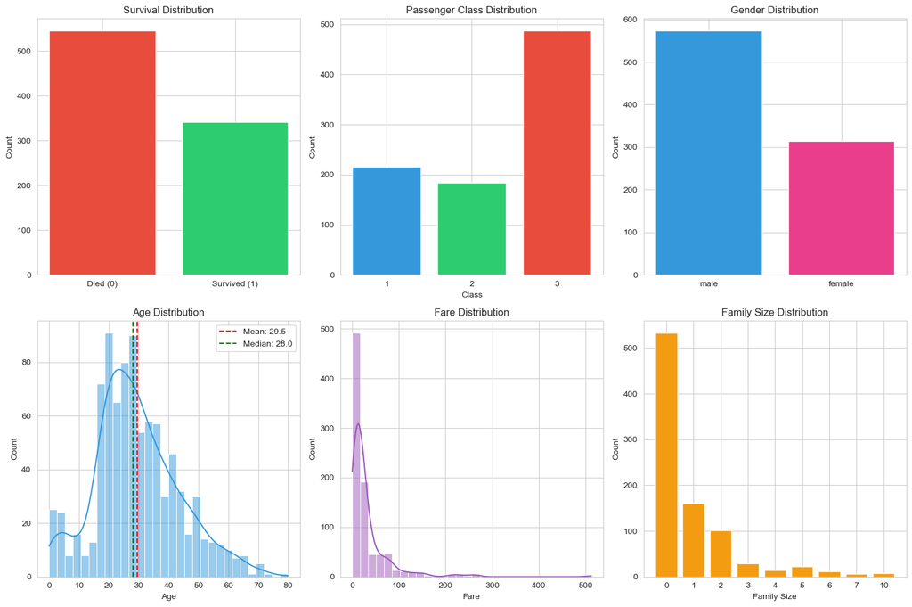

```python
print("\n4. Univariate Analysis:")
print("=" * 40)

fig, axes = plt.subplots(2, 3, figsize=(15, 10))

# 1. Survival Distribution
survival_counts = df['Survived'].value_counts()
survival_percent = round((survival_counts / len(df)) * 100, 1)

axes[0, 0].bar(['Died (0)', 'Survived (1)'], survival_counts.values, color=['#e74c3c', '#2ecc71'])
axes[0, 0].set_title('Survival Distribution')
axes[0, 0].set_ylabel('Count')

# 2. Passenger Class Distribution
pclass_counts = df['Pclass'].value_counts().sort_index()
axes[0, 1].bar(pclass_counts.index.astype(str), pclass_counts.values, color=['#3498db', '#2ecc71', '#e74c3c'])
axes[0, 1].set_title('Passenger Class Distribution')
axes[0, 1].set_xlabel('Class')
axes[0, 1].set_ylabel('Count')

# 3. Gender Distribution
gender_counts = df['Sex'].value_counts()
axes[0, 2].bar(gender_counts.index, gender_counts.values, color=['#3498db', '#e83e8c'])
axes[0, 2].set_title('Gender Distribution')
axes[0, 2].set_ylabel('Count')

# 4. Age Distribution with KDE
sns.histplot(df['Age'], kde=True, ax=axes[1, 0], bins=30, color='#3498db')
axes[1, 0].axvline(df['Age'].mean(), color='red', linestyle='--', label=f'Mean: {df["Age"].mean():.1f}')
axes[1, 0].axvline(df['Age'].median(), color='green', linestyle='--', label=f'Median: {df["Age"].median():.1f}')
axes[1, 0].set_title('Age Distribution')
axes[1, 0].set_xlabel('Age')
axes[1, 0].legend()

# 5. Fare Distribution
sns.histplot(df['Fare'], kde=True, ax=axes[1, 1], bins=30, color='#9b59b6')
axes[1, 1].set_title('Fare Distribution')
axes[1, 1].set_xlabel('Fare')

# 6. Family Size (New Feature)
df['FamilySize'] = df['Siblings/Spouses Aboard'] + df['Parents/Children Aboard']
family_counts = df['FamilySize'].value_counts().sort_index()
axes[1, 2].bar(family_counts.index.astype(str), family_counts.values, color='#f39c12')
axes[1, 2].set_title('Family Size Distribution')
axes[1, 2].set_xlabel('Family Size')
axes[1, 2].set_ylabel('Count')

import os
if not os.path.exists('images'):
    os.makedirs('images')
plt.tight_layout()
plt.savefig('images/univariate_analysis.png', dpi=300, bbox_inches='tight')
plt.show()
```

### Key Statistics: (By visualizations analysis)

- Overall survival rate: 38.6%
- Most common passenger class: 3 (487 passengers)
- Gender ratio (M/F): 1.82:1
- Average age: 29.5 years
- Median fare: $14.45
- Most common family size: 0 members

### MULTIVARIATE ANALYSIS:

```
5. Multivariate Analysis:
========================================
```

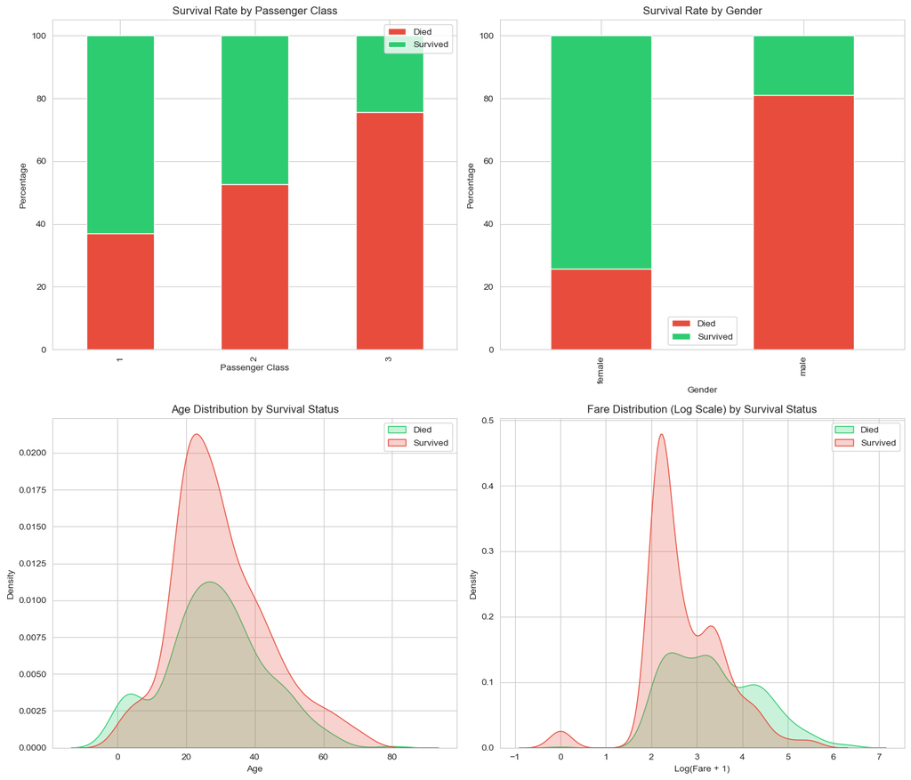

```python
print("\n5. Multivariate Analysis:")
print("=" * 40)
fig, axes = plt.subplots(2, 2, figsize=(14, 12))

# 1. Survival by Passenger Class
survival_by_class = pd.crosstab(df['Survived'], df['Pclass'], normalize='columns') * 100
survival_by_class.T.plot(kind='bar', stacked=True, ax=axes[0, 0], color=['#e74c3c', '#2ecc71'])
axes[0, 0].set_title('Survival Rate by Passenger Class', fontsize=12)
axes[0, 0].set_xlabel('Passenger Class')
axes[0, 0].set_ylabel('Percentage')
axes[0, 0].legend(['Died', 'Survived'])

# 2. Survival by Gender
survival_by_gender = pd.crosstab(df['Survived'], df['Sex'], normalize='columns') * 100
survival_by_gender.T.plot(kind='bar', stacked=True, ax=axes[0, 1],  color=['#e74c3c', '#2ecc71'])
axes[0, 1].set_title('Survival Rate by Gender', fontsize=12)
axes[0, 1].set_xlabel('Gender')
axes[0, 1].set_ylabel('Percentage')
axes[0, 1].legend(['Died', 'Survived'])

# 3. Age Distribution by Survival
sns.kdeplot(data=df, x='Age', hue='Survived', ax=axes[1, 0], fill=True, palette=['#e74c3c', '#2ecc71'])
axes[1, 0].set_title('Age Distribution by Survival Status', fontsize=12)
axes[1, 0].set_xlabel('Age')
axes[1, 0].set_ylabel('Density')
axes[1, 0].legend(['Died', 'Survived'])

# 4. Fare Distribution by Survival
# Created a new column for log fare to handle skewness
df['LogFare'] = np.log1p(df['Fare'])
sns.kdeplot(data=df, x='LogFare', hue='Survived', ax=axes[1, 1], fill=True, palette=['#e74c3c', '#2ecc71'])
axes[1, 1].set_title('Fare Distribution (Log Scale) by Survival Status', fontsize=12)
axes[1, 1].set_xlabel('Log(Fare + 1)')
axes[1, 1].set_ylabel('Density')
axes[1, 1].legend(['Died', 'Survived'])

plt.tight_layout()
plt.savefig('images/multivariate_analysis.png', dpi=300, bbox_inches='tight')
plt.show()
```

```
Correlation Analysis:
```

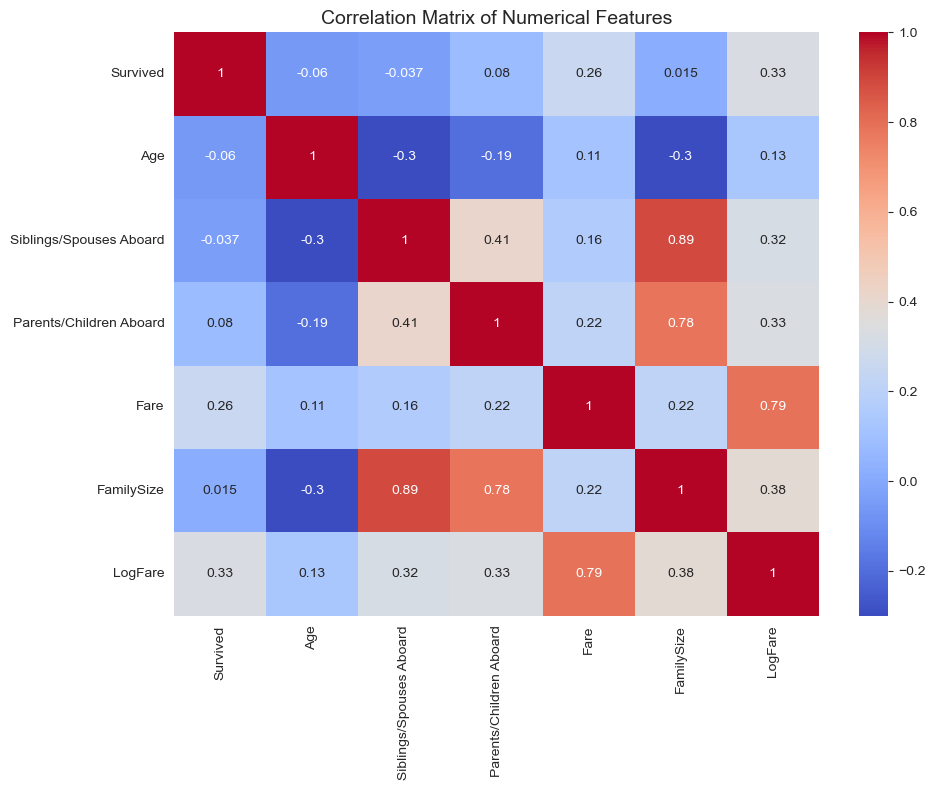

```python
# 5. Correlation Heatmap
print("\nCorrelation Analysis:")
plt.figure(figsize=(10, 8))
numeric_cols = df.select_dtypes(include=[np.number]).columns
correlation_matrix = df[numeric_cols].corr()
sns.heatmap(correlation_matrix, annot=True, cmap='coolwarm')
plt.title('Correlation Matrix of Numerical Features', fontsize=14)
plt.tight_layout()
plt.savefig('images/correlation_matrix.png', dpi=300, bbox_inches='tight')
plt.show()
```

### Key Insights from Multivariate Analysis:

1. Passenger Class Impact:
   - Class 1: 63.0% survival rate
   - Class 2: 47.3% survival rate
   - Class 3: 24.4% survival rate
2. Gender Impact:
   - Female: 74.2% survival rate
   - Male: 19.0% survival rate
3. Age Impact:
   - Average age of survivors: 28.4 years
   - Average age of non-survivors: 30.1 years
4. Fare Impact:
   - Median fare for survivors: $26.00
   - Median fare for non-survivors: $10.50

### FEATURE ENGINEERING:

```python
print("\n6. Feature Engineering:")
print("=" * 40)

# Creating new features
df['Title'] = df['Name'].str.extract(' ([A-Za-z]+)\.', expand=False)
df['IsAlone'] = (df['FamilySize'] == 0).astype(int)
df['AgeGroup'] = pd.cut(df['Age'],
                        bins=[0, 12, 18, 35, 60, 100],
                        labels=['Child', 'Teen', 'Young Adult', 'Adult', 'Senior'])

# Survival rate by new features
print("\nSurvival rate by new features:")

# Travel alone vs with family
alone_survival = df.groupby('IsAlone')['Survived'].mean()
print(f"\nTraveling alone: {alone_survival[1]*100:.1f}% survival")
print(f"Traveling with family: {alone_survival[0]*100:.1f}% survival")

# Age group analysis
agegroup_survival = df.groupby('AgeGroup', observed=True)['Survived'].mean()
print(f"\nSurvival by age group:")
for agegroup, rate in agegroup_survival.items():
    print(f"   - {agegroup}: {rate*100:.1f}%")
```

```
6. Feature Engineering:
========================================

Survival rate by new features:

Traveling alone: 30.6% survival
Traveling with family: 50.6% survival

Survival by age group:
   - Child: 50.0%
   - Teen: 40.2%
   - Young Adult: 36.4%
   - Adult: 39.0%
   - Senior: 19.2%
```

## FINAL CONCLUSIONS:

### KEY FINDINGS:

   c. Fare: Higher fares correlated with better survival chances

### BUSINESS IMPLICATIONS:

1. Priority seating/evacuation procedures should consider passenger demographics
2. Higher fare classes showed better survival - potentially due to cabin location
3. 'Women and children first' policy was evident in the data